# Supervised Learning Capstone 2020

This data is called Graduate Admission 2 owned by Mohan S. Acharya. According to its bio in Kaggle, the dataset was inspired by a UCLA Graduate Dataset. I also want to acknowledge that the data set was "created for prediction of Graduate Admissions from an Indian perspective."

Why did I choose this dataset?: I appreciated and resonated with the inspiration under the description of the dataset. As someone who applied to my first choice graduate program twice, understanding how these factors play out to predict admission can really help students, who want to go to graduate school, better prepare their resume.

*Citation: Mohan S Acharya, Asfia Armaan, Aneeta S Antony : A Comparison of Regression Models for Prediction of Graduate Admissions, IEEE International Conference on Computational Intelligence in Data Science 2019

In this Supervised Learning Capstone, I will take the Graduate Admission 2 data and evaluate which algorithm provides the best predictive model.

Order of Contents: 1) Import of data 2) Data Cleaning 3) Exploratory Data Analysis -Univariate Analysis -Bivariate Analysis -Visualizations 4) Train model 5) Decision Tree Regressor - hyperparameters tuning and prediction 5) KNN - hyperparameters tuning and prediction 5) SVM - hyperparameters tuning and prediction 6) Model Evaluations 7) Conclusion

```python
import numpy as np
import pandas as pd
import matplotlib.pyplot as plt
from sklearn.preprocessing import StandardScaler
from sklearn import preprocessing
import seaborn as sns
%matplotlib inline
from sklearn.model_selection import GridSearchCV
from sklearn import svm, datasets
from sklearn.model_selection import train_test_split
from sklearn.tree import DecisionTreeRegressor
from sklearn.neighbors import KNeighborsRegressor
from sklearn.model_selection import cross_val_score
from sklearn.metrics import r2_score,mean_squared_error
from sklearn import neighbors
from sklearn.svm import SVR
```

```python
admission = pd.read_csv(r"/Users/pangmoua/Admission_predict.csv")
```

```python
admission.head(30)
```

|  | Serial No. | GRE Score | TOEFL Score | University Rating | SOP | LOR | CGPA | Research | Chance of Admit |
| --- | --- | --- | --- | --- | --- | --- | --- | --- | --- |
| 0 | 1 | 337 | 118 | 4 | 4.5 | 4.5 | 9.65 | 1 | 0.92 |
| 1 | 2 | 324 | 107 | 4 | 4.0 | 4.5 | 8.87 | 1 | 0.76 |
| 2 | 3 | 316 | 104 | 3 | 3.0 | 3.5 | 8.00 | 1 | 0.72 |
| 3 | 4 | 322 | 110 | 3 | 3.5 | 2.5 | 8.67 | 1 | 0.80 |
| 4 | 5 | 314 | 103 | 2 | 2.0 | 3.0 | 8.21 | 0 | 0.65 |
| 5 | 6 | 330 | 115 | 5 | 4.5 | 3.0 | 9.34 | 1 | 0.90 |
| 6 | 7 | 321 | 109 | 3 | 3.0 | 4.0 | 8.20 | 1 | 0.75 |
| 7 | 8 | 308 | 101 | 2 | 3.0 | 4.0 | 7.90 | 0 | 0.68 |
| 8 | 9 | 302 | 102 | 1 | 2.0 | 1.5 | 8.00 | 0 | 0.50 |
| 9 | 10 | 323 | 108 | 3 | 3.5 | 3.0 | 8.60 | 0 | 0.45 |
| 10 | 11 | 325 | 106 | 3 | 3.5 | 4.0 | 8.40 | 1 | 0.52 |
| 11 | 12 | 327 | 111 | 4 | 4.0 | 4.5 | 9.00 | 1 | 0.84 |
| 12 | 13 | 328 | 112 | 4 | 4.0 | 4.5 | 9.10 | 1 | 0.78 |
| 13 | 14 | 307 | 109 | 3 | 4.0 | 3.0 | 8.00 | 1 | 0.62 |
| 14 | 15 | 311 | 104 | 3 | 3.5 | 2.0 | 8.20 | 1 | 0.61 |
| 15 | 16 | 314 | 105 | 3 | 3.5 | 2.5 | 8.30 | 0 | 0.54 |
| 16 | 17 | 317 | 107 | 3 | 4.0 | 3.0 | 8.70 | 0 | 0.66 |
| 17 | 18 | 319 | 106 | 3 | 4.0 | 3.0 | 8.00 | 1 | 0.65 |
| 18 | 19 | 318 | 110 | 3 | 4.0 | 3.0 | 8.80 | 0 | 0.63 |
| 19 | 20 | 303 | 102 | 3 | 3.5 | 3.0 | 8.50 | 0 | 0.62 |
| 20 | 21 | 312 | 107 | 3 | 3.0 | 2.0 | 7.90 | 1 | 0.64 |
| 21 | 22 | 325 | 114 | 4 | 3.0 | 2.0 | 8.40 | 0 | 0.70 |
| 22 | 23 | 328 | 116 | 5 | 5.0 | 5.0 | 9.50 | 1 | 0.94 |
| 23 | 24 | 334 | 119 | 5 | 5.0 | 4.5 | 9.70 | 1 | 0.95 |
| 24 | 25 | 336 | 119 | 5 | 4.0 | 3.5 | 9.80 | 1 | 0.97 |
| 25 | 26 | 340 | 120 | 5 | 4.5 | 4.5 | 9.60 | 1 | 0.94 |
| 26 | 27 | 322 | 109 | 5 | 4.5 | 3.5 | 8.80 | 0 | 0.76 |
| 27 | 28 | 298 | 98 | 2 | 1.5 | 2.5 | 7.50 | 1 | 0.44 |
| 28 | 29 | 295 | 93 | 1 | 2.0 | 2.0 | 7.20 | 0 | 0.46 |
| 29 | 30 | 310 | 99 | 2 | 1.5 | 2.0 | 7.30 | 0 | 0.54 |

```python
#data cleaning
```

```python
admission.Research.dtypes
```

```
dtype('int64')
```

```python
admission.isnull().sum()*100/admission.isnull().count()
```

```
Serial No.           0.0
GRE Score            0.0
TOEFL Score          0.0
University Rating    0.0
SOP                  0.0
LOR                  0.0
CGPA                 0.0
Research             0.0
Chance of Admit      0.0
dtype: float64
```

```python
admission.columns
```

```
Index(['Serial No.', 'GRE Score', 'TOEFL Score', 'University Rating', 'SOP',
       'LOR ', 'CGPA', 'Research', 'Chance of Admit '],
      dtype='object')
```

```python
var_admin = admission.iloc[:,1:8]
```

```python
lst=[]
for i in var_admin.columns:
    lst.append(admission[str(i)].nunique())
```

```python
print(pd.DataFrame(lst))
```

```
     0
0   49
1   29
2    5
3    9
4    9
5  168
6    2
```

```python
#write loop to check for nan values
```

```python
for col in var_admin:
    print(col)
    print(var_admin[col].unique().tolist())
```

```
GRE Score
[337, 324, 316, 322, 314, 330, 321, 308, 302, 323, 325, 327, 328, 307, 311, 317, 319, 318, 303, 312, 334, 336, 340, 298, 295, 310, 300, 338, 331, 320, 299, 304, 313, 332, 326, 329, 339, 309, 315, 301, 296, 294, 306, 305, 290, 335, 333, 297, 293]
TOEFL Score
[118, 107, 104, 110, 103, 115, 109, 101, 102, 108, 106, 111, 112, 105, 114, 116, 119, 120, 98, 93, 99, 97, 117, 113, 100, 95, 96, 94, 92]
University Rating
[4, 3, 2, 5, 1]
SOP
[4.5, 4.0, 3.0, 3.5, 2.0, 5.0, 1.5, 1.0, 2.5]
LOR
[4.5, 3.5, 2.5, 3.0, 4.0, 1.5, 2.0, 5.0, 1.0]
CGPA
[9.65, 8.87, 8.0, 8.67, 8.21, 9.34, 8.2, 7.9, 8.6, 8.4, 9.0, 9.1, 8.3, 8.7, 8.8, 8.5, 9.5, 9.7, 9.8, 9.6, 7.5, 7.2, 7.3, 8.1, 9.4, 9.2, 7.8, 7.7, 9.3, 8.85, 7.4, 7.6, 6.8, 8.92, 9.02, 8.64, 9.22, 9.16, 9.64, 9.76, 9.45, 9.04, 8.9, 8.56, 8.72, 8.22, 7.54, 7.36, 8.02, 9.36, 8.66, 8.42, 8.28, 8.14, 8.7…
Research
[1, 0]
```

```python
admission.isna().sum()/len(admission)
```

```
Serial No.           0.0
GRE Score            0.0
TOEFL Score          0.0
University Rating    0.0
SOP                  0.0
LOR                  0.0
CGPA                 0.0
Research             0.0
Chance of Admit      0.0
dtype: float64
```

```python
#there are no nan values. Great!
```

```python
#data summary
#GRE Scores ( out of 340 )
#TOEFL Scores ( out of 120 )
#University Rating ( out of 5 )
#Statement of Purpose and Letter of Recommendation Strength ( out of 5 )
#Undergraduate GPA ( out of 10 )
#Research Experience ( either 0 or 1 )
#Chance of Admit ( ranging from 0 to 1 )
```

Exploratory Data Analysis

```python
#univariate
```

```python
admission.shape
```

```
(400, 9)
```

```python
admission.info()
```

```
<class 'pandas.core.frame.DataFrame'>
RangeIndex: 400 entries, 0 to 399
Data columns (total 9 columns):
Serial No.           400 non-null int64
GRE Score            400 non-null int64
TOEFL Score          400 non-null int64
University Rating    400 non-null int64
SOP                  400 non-null float64
LOR                  400 non-null float64
CGPA                 400 non-null float64
Research             400 non-null int64
Chance of Admit      400 non-null float64
dtypes: float64(4), int64(5)
memory usage: 28.2 KB
```

```python
admission.describe()
```

|  | Serial No. | GRE Score | TOEFL Score | University Rating | SOP | LOR | CGPA | Research | Chance of Admit |
| --- | --- | --- | --- | --- | --- | --- | --- | --- | --- |
| count | 400.000000 | 400.000000 | 400.000000 | 400.000000 | 400.000000 | 400.000000 | 400.000000 | 400.000000 | 400.000000 |
| mean | 200.500000 | 316.807500 | 107.410000 | 3.087500 | 3.400000 | 3.452500 | 8.598925 | 0.547500 | 0.724350 |
| std | 115.614301 | 11.473646 | 6.069514 | 1.143728 | 1.006869 | 0.898478 | 0.596317 | 0.498362 | 0.142609 |
| min | 1.000000 | 290.000000 | 92.000000 | 1.000000 | 1.000000 | 1.000000 | 6.800000 | 0.000000 | 0.340000 |
| 25% | 100.750000 | 308.000000 | 103.000000 | 2.000000 | 2.500000 | 3.000000 | 8.170000 | 0.000000 | 0.640000 |
| 50% | 200.500000 | 317.000000 | 107.000000 | 3.000000 | 3.500000 | 3.500000 | 8.610000 | 1.000000 | 0.730000 |
| 75% | 300.250000 | 325.000000 | 112.000000 | 4.000000 | 4.000000 | 4.000000 | 9.062500 | 1.000000 | 0.830000 |
| max | 400.000000 | 340.000000 | 120.000000 | 5.000000 | 5.000000 | 5.000000 | 9.920000 | 1.000000 | 0.970000 |

```python
admission.columns
```

```
Index(['Serial No.', 'GRE Score', 'TOEFL Score', 'University Rating', 'SOP',
       'LOR ', 'CGPA', 'Research', 'Chance of Admit '],
      dtype='object')
```

```python
#take out column 0
#Targeted variable is Chance of Admit
```

```python
admin = admission.iloc[:,1:]
admin = pd.DataFrame(admin)
```

```python
#Visualize distribution of variables
```

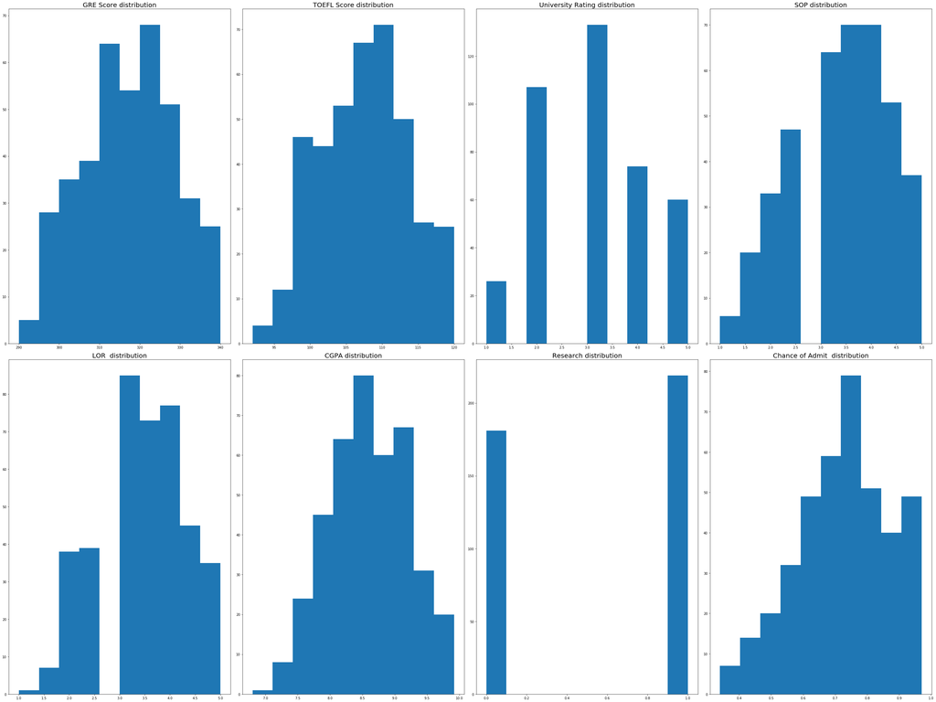

```python
plt.figure(figsize=(40,30))
num=0
for i in admin.columns:
    num+=1
    plt.subplot(2,4, num)
    plt.tight_layout()
    plt.hist(admission[str(i)])
    plt.title((i+ ' distribution'), loc='center', fontsize=20, fontweight=0)
    plt.savefig('admin.png')
```

```python
#check for outliers
```

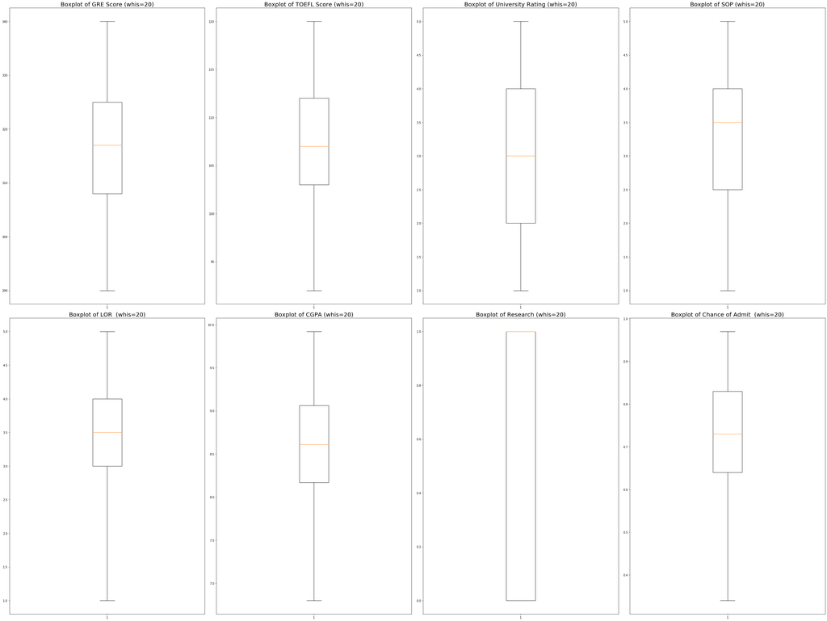

```python
plt.figure(figsize=(40,30))
num=0
for i in admin.columns:
    num+=1
    plt.subplot(2,4, num)
    plt.tight_layout()
    plt.boxplot(admission[str(i)], whis=20)
    plt.title(('Boxplot of ' +i +' (whis=20)'), loc='center', fontsize=20, fontweight=0)
```

```python
#no outliers
```

Bivariate analysis of two continuous variables- comparing potential features to target

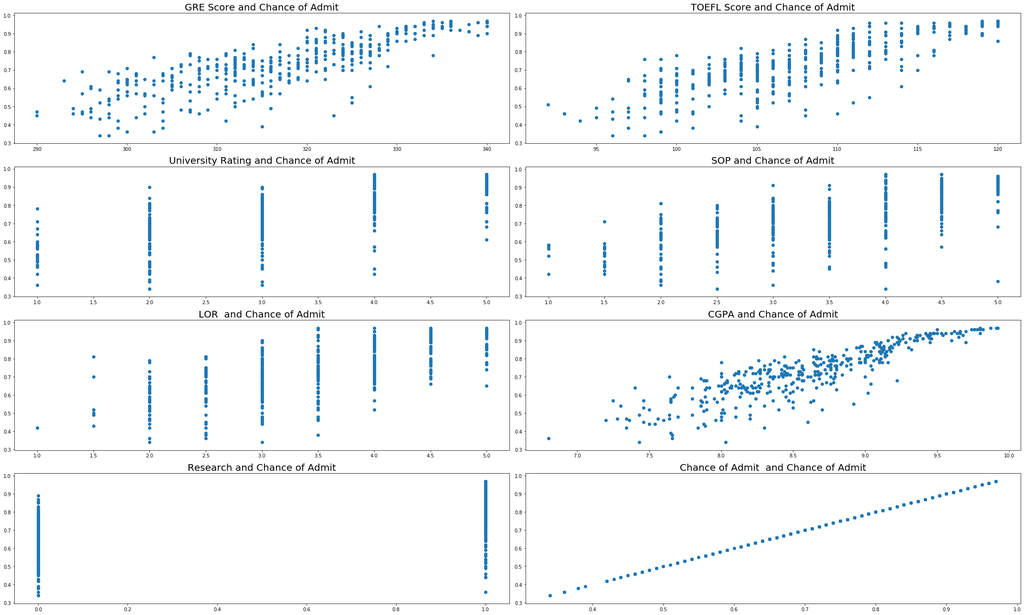

```python
plt.figure(figsize=(30,18))
num=0
for i in admin.columns:
    num+=1
    plt.subplot(4,2, num)
    plt.tight_layout()
    plt.scatter(admin[str(i)], admission["Chance of Admit "])
    plt.title((i+ " and Chance of Admit"), loc='center', fontsize=20, fontweight=0)
```

```python
admin.corr()
```

|  | GRE Score | TOEFL Score | University Rating | SOP | LOR | CGPA | Research | Chance of Admit |
| --- | --- | --- | --- | --- | --- | --- | --- | --- |
| GRE Score | 1.000000 | 0.835977 | 0.668976 | 0.612831 | 0.557555 | 0.833060 | 0.580391 | 0.802610 |
| TOEFL Score | 0.835977 | 1.000000 | 0.695590 | 0.657981 | 0.567721 | 0.828417 | 0.489858 | 0.791594 |
| University Rating | 0.668976 | 0.695590 | 1.000000 | 0.734523 | 0.660123 | 0.746479 | 0.447783 | 0.711250 |
| SOP | 0.612831 | 0.657981 | 0.734523 | 1.000000 | 0.729593 | 0.718144 | 0.444029 | 0.675732 |
| LOR | 0.557555 | 0.567721 | 0.660123 | 0.729593 | 1.000000 | 0.670211 | 0.396859 | 0.669889 |
| CGPA | 0.833060 | 0.828417 | 0.746479 | 0.718144 | 0.670211 | 1.000000 | 0.521654 | 0.873289 |
| Research | 0.580391 | 0.489858 | 0.447783 | 0.444029 | 0.396859 | 0.521654 | 1.000000 | 0.553202 |
| Chance of Admit | 0.802610 | 0.791594 | 0.711250 | 0.675732 | 0.669889 | 0.873289 | 0.553202 | 1.000000 |

```python
#highly correlated independents: GRE Score, TOEFL Score, and CGPA
#higher than .8 and lower than 1 indicates multicol between independent variables (CGPA-GRE Score)
```

```python
corrmat_admission = admin.corr()
```

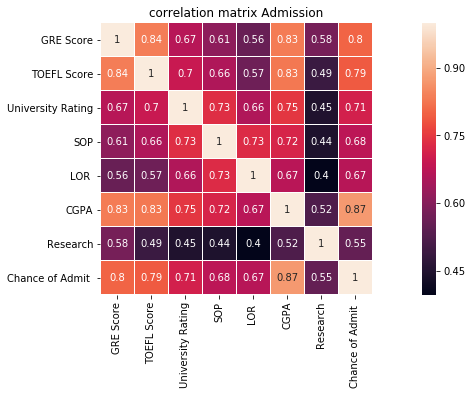

```python
plt.figure(figsize=(18,5))

plt.subplot(1,1,1)
sns.heatmap(corrmat_admission, square=True, annot=True, linewidths=.5)
plt.title("correlation matrix Admission")

plt.show()
```

when looking at correlation - look just at independent vs. independent, Test scores are highly correlated